# Warren_Navpreet_turn_in

# Gathering data sets for NYC zipcodes and asc data (which consists of the SES features)

First, we have to insert our libraries, zip codes, and data files to make sure we have NYC zip codes and SES data.

```r
library(tidyverse)
library(tidycensus)
library(tigris)
#uncomment below and run it in case there's an error with tibbles
#install.packages("sf")
library(sf)
options(tigris_use_cache = TRUE)

load("census_2016_data.RData")

#in case you need this
#census_api_key("KEY_GOES_HERE", install = TRUE)

#grab the zip codes for NYC
# came from this link https://github.com/nychealth/coronavirus-data/blob/097cbd70aa00eb635b17b177bc4546b2fce21895/tests-by-zcta.csv
zippy <- read.csv("April_1_pos_tests.csv")
zippy <- zippy %>% mutate(GEOID = MODZCTA)
zippy <- zippy %>% mutate(prop_COVID = Positive/Total)
```

# Comparing summary statistics with the report

We started off by comparing the medians and confidence intervals for each of the variables, plotting the data on a map, and create a univariate regression model with the results from the paper.

We grab the proportion of 18-64 year old population that is uninsured. We'll make a table, a linear model and summarize all of that data to compare the results from the paper.

```
## [1] 0.13636
```

```
##        25%
## 0.08630227
```

```
##       75%
## 0.1733998
```

Results from the median and quartile ranges for the uninsured population were consistent with the ones written in the paper. The median was 13.6% (8.6%-17.3%) in comparison to 13%(9-17%) from the paper.

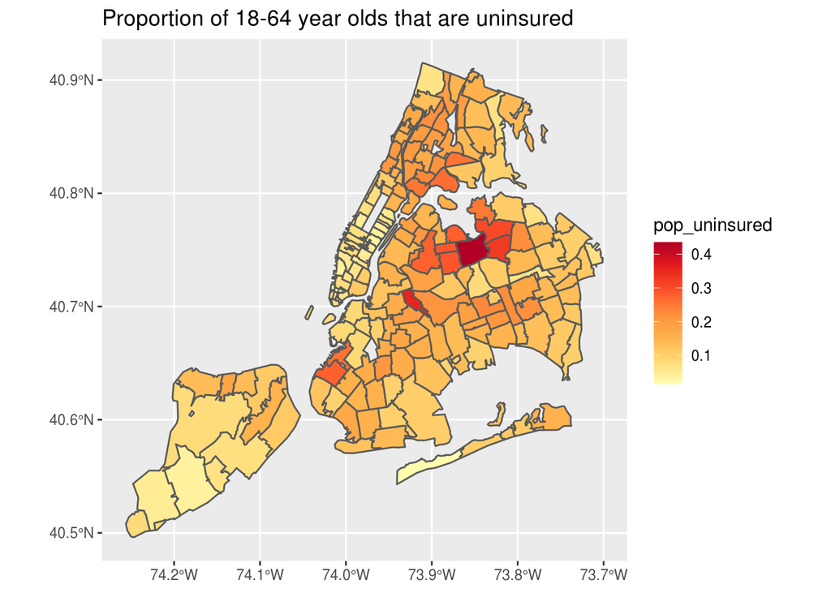

```r
#graph it on the map of nyc
ggplot(data = df_uninsured, aes(fill = pop_uninsured)) +
  geom_sf() +
  scale_fill_distiller(palette = "YlOrRd",
                       direction = 1) +
  ggtitle("Proportion of 18-64 year olds that are uninsured")
```

```r
#make a linear model
uninsured_model <- lm(prop_COVID ~ pop_uninsured, data = df_uninsured)

#get summary
summary(uninsured_model)
```

```
##
## Call:
## lm(formula = prop_COVID ~ pop_uninsured, data = df_uninsured)
##
## Residuals:
##       Min        1Q    Median        3Q       Max
## -0.195473 -0.050727  0.000034  0.049606  0.192270
##
## Coefficients:
##               Estimate Std. Error t value Pr(>|t|)
## (Intercept)    0.40028    0.01311  30.525   <2e-16 ***
## pop_uninsured  0.80229    0.08460   9.483   <2e-16 ***
## ---
## Signif. codes:  0 '***' 0.001 '**' 0.01 '*' 0.05 '.' 0.1 ' ' 1
##
## Residual standard error: 0.07708 on 175 degrees of freedom
## Multiple R-squared:  0.3395, Adjusted R-squared:  0.3357
## F-statistic: 89.93 on 1 and 175 DF,  p-value: < 2.2e-16
```

The regression results showed a r-squared value of 34% in comparison to the 38% from the paper.

Next we grab income. And do the same: make a map, a linear model, and a summary.

```r
#get income data

#make zip code numeric, to match type with the other one
med_inc$GEOID <- as.numeric(med_inc$GEOID)

#join to keep the NYC zip codes
med_inc <-  inner_join(med_inc, zippy, by="GEOID")

#get rid of extra columns
med_inc <- med_inc[, -c(5:7)]

#median and confidence intervals
median(med_inc$income)
```

```
## [1] 60526
```

```r
quantile(med_inc$income, 0.25)
```

```
##   25%
## 45643
```

```r
quantile(med_inc$income, 0.75)
```

```
##   75%
## 81678
```

The results for the median values were only a couple of thousands off from the paper (since our median did not take into account weight of each zip code like Jake mentioned). The median value was 60,526 (45,643-81,678).

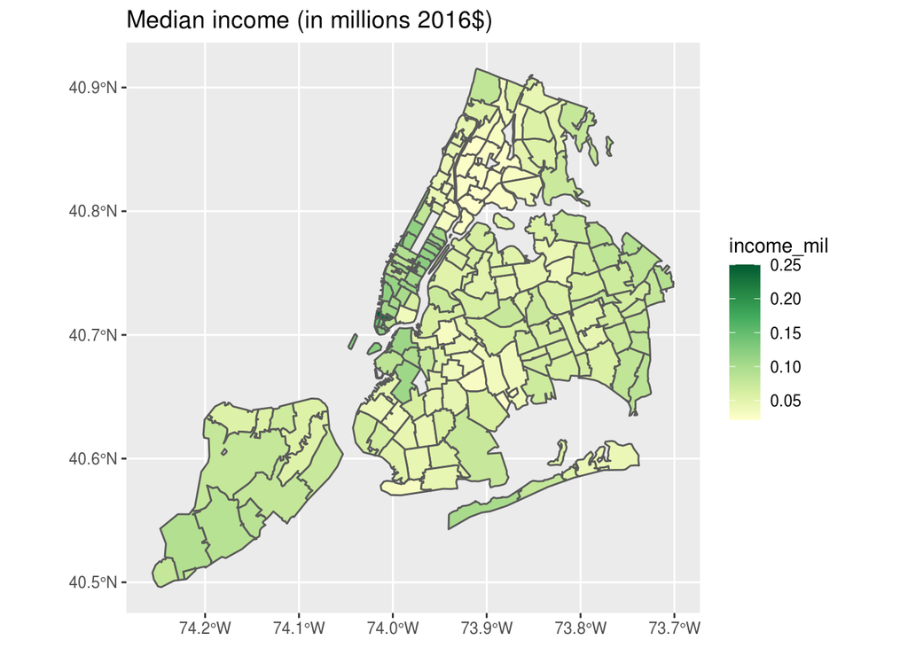

```r
#graph on a map
#make columns to take in millions
med_inc <- med_inc %>% mutate(income_mil = income/1000000)

#graph
ggplot(data = med_inc, aes(fill = income_mil)) +
  geom_sf() +
  scale_fill_distiller(palette = "YlGn",
                       direction = 1) +
  ggtitle("Median income (in millions 2016$)")
```

```r
#linear model, then summarise
income_model <- lm(prop_COVID ~ income_mil, data = med_inc)

summary(income_model)
```

```
##
## Call:
## lm(formula = prop_COVID ~ income_mil, data = med_inc)
##
## Residuals:
##       Min        1Q    Median        3Q       Max
## -0.173311 -0.054852 -0.002961  0.046015  0.266226
##
## Coefficients:
##             Estimate Std. Error t value Pr(>|t|)
## (Intercept)  0.61395    0.01348  45.556  < 2e-16 ***
## income_mil  -1.52071    0.17968  -8.464 1.01e-14 ***
## ---
## Signif. codes:  0 '***' 0.001 '**' 0.01 '*' 0.05 '.' 0.1 ' ' 1
##
## Residual standard error: 0.07989 on 175 degrees of freedom
## Multiple R-squared:  0.2904, Adjusted R-squared:  0.2864
## F-statistic: 71.63 on 1 and 175 DF,  p-value: 1.009e-14
```

The results for the univariate regression was 29% which was close to the results from the paper (32%).

Now we do the same for proportion of people who identify as white.

```r
#rinse and repeat
race_white$GEOID <- as.numeric(race_white$GEOID)
race_white <-  inner_join(race_white, zippy, by="GEOID")
race_white <- race_white[, -c(7:9)]

#divide to get portion
race_white <- race_white %>% mutate(prop_white = whiteE / totE)

median(race_white$prop_white)
```

```
## [1] 0.4842297
```

```r
quantile(race_white$prop_white, 0.25)
```

```
##       25%
## 0.2266178
```

```r
quantile(race_white$prop_white, 0.75)
```

```
##       75%
## 0.6978357
```

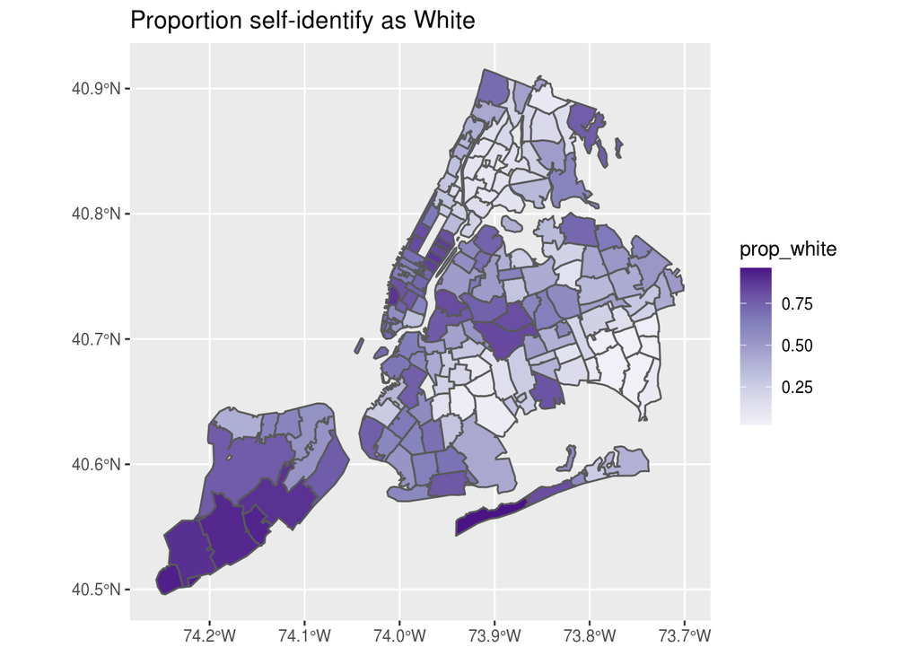

```r
ggplot(data = race_white, aes(fill = prop_white)) +
  geom_sf() +
  scale_fill_distiller(palette = "Purples",
                       direction = 1) +
  ggtitle("Proportion self-identify as White")
```

```r
#linear regression model
race_model <- lm(prop_COVID ~ prop_white, data = race_white)

summary(race_model)
```

```
##
## Call:
## lm(formula = prop_COVID ~ prop_white, data = race_white)
##
## Residuals:
##       Min        1Q    Median        3Q       Max
## -0.221742 -0.049154 -0.002856  0.048653  0.248975
##
## Coefficients:
##             Estimate Std. Error t value Pr(>|t|)
## (Intercept)  0.60952    0.01191  51.168   <2e-16 ***
## prop_white  -0.20884    0.02223  -9.394   <2e-16 ***
## ---
## Signif. codes:  0 '***' 0.001 '**' 0.01 '*' 0.05 '.' 0.1 ' ' 1
##
## Residual standard error: 0.07733 on 175 degrees of freedom
## Multiple R-squared:  0.3352, Adjusted R-squared:  0.3314
## F-statistic: 88.26 on 1 and 175 DF,  p-value: < 2.2e-16
```

For regression the r-squared value was 33.52% which is very close to the 34% mentioned in the paper.

Now we do the same for house size. Note this one has more calls since the data is very segmented.

```r
#same as the previous
house_size$GEOID <- as.numeric(house_size$GEOID)
house_size <-  inner_join(house_size, zippy, by="GEOID")

house_size <- house_size[, -c(21:23)]

#get proportions
house_size <- house_size %>% mutate(prop_four_up =  (fourE + fiveE + sixE + sev_moreE +
                                    nfamfourE + nfamfiveE +nfamsixE + nfamsev_moreE) / totalE )

median(house_size$prop_four_up)
```

```
## [1] 0.2385453
```

```r
quantile(house_size$prop_four_up, 0.25)
```

```
##       25%
## 0.1493927
```

```r
quantile(house_size$prop_four_up, 0.75)
```

```
##       75%
## 0.3114455
```

Results for the proportion in households of 4 or more showed a median of 24%(15%-31%), in comparison to the 25%(15.1%-30.7%).

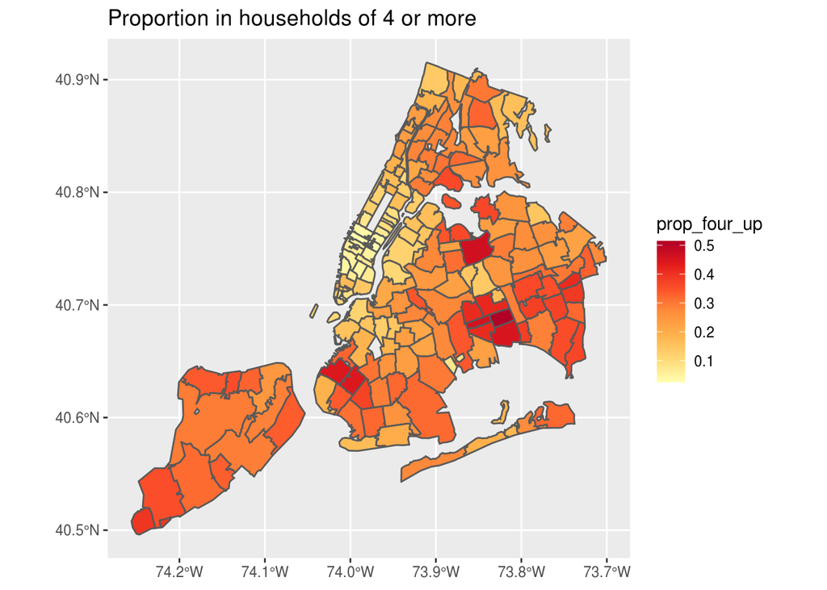

```r
ggplot(data = house_size, aes(fill = prop_four_up)) +
  geom_sf() +
  scale_fill_distiller(palette = "YlOrRd",
                       direction = 1) +
  ggtitle("Proportion in households of 4 or more")
```

```r
house_model <- lm(prop_COVID ~ prop_four_up, data = house_size)

summary(house_model)
```

```
##
## Call:
## lm(formula = prop_COVID ~ prop_four_up, data = house_size)
##
## Residuals:
##       Min        1Q    Median        3Q       Max
## -0.180613 -0.047837  0.005599  0.045047  0.233232
##
## Coefficients:
##              Estimate Std. Error t value Pr(>|t|)
## (Intercept)   0.38225    0.01338   28.57   <2e-16 ***
## prop_four_up  0.55413    0.05206   10.64   <2e-16 ***
## ---
## Signif. codes:  0 '***' 0.001 '**' 0.01 '*' 0.05 '.' 0.1 ' ' 1
##
## Residual standard error: 0.07389 on 175 degrees of freedom
## Multiple R-squared:  0.393,  Adjusted R-squared:  0.3895
## F-statistic: 113.3 on 1 and 175 DF,  p-value: < 2.2e-16
```

The r-squared value from the regression model was 39.3%.

Now the same for people taking the bus.

```r
pub_trans$GEOID <- as.numeric(pub_trans$GEOID)
pub_trans <-  inner_join(pub_trans, zippy, by="GEOID")

pub_trans <- pub_trans[, -c(7:9)]

pub_trans <- pub_trans %>% mutate(prop_bus = busE/totalE)

median(pub_trans$prop_bus)
```

```
## [1] 0.09612272
```

```r
quantile(pub_trans$prop_bus, 0.25)
```

```
##        25%
## 0.06403574
```

```r
quantile(pub_trans$prop_bus, 0.75)
```

```
##       75%
## 0.1493845
```

The median values above are compared to the values from the paper which were 9.7%(6.5-15%).

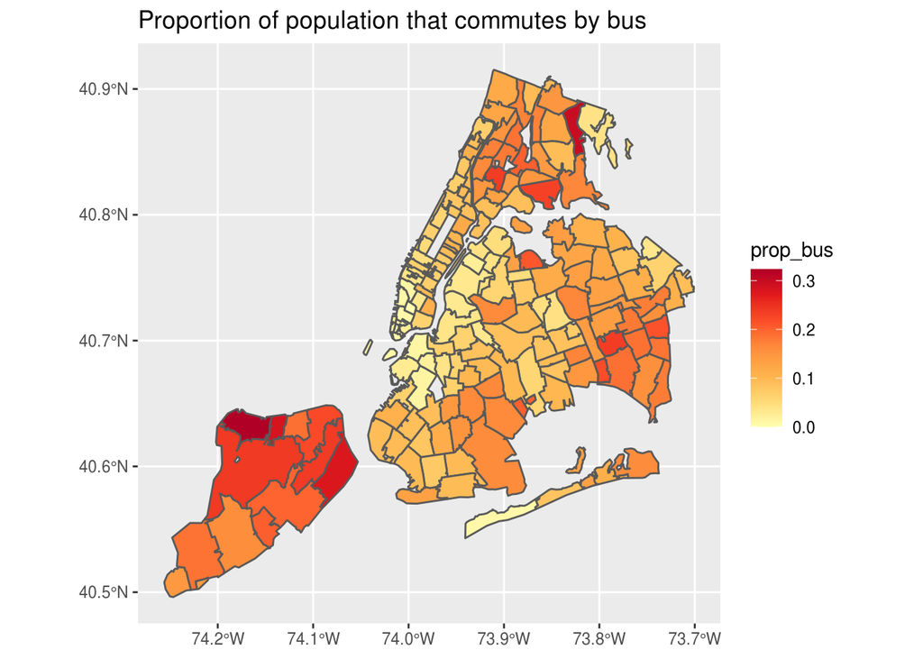

```r
ggplot(data = pub_trans, aes(fill = prop_bus)) +
  geom_sf() +
  scale_fill_distiller(palette = "YlOrRd",
                       direction = 1) +
  ggtitle("Proportion of population that commutes by bus")
```

```r
bus_model <- lm(prop_COVID ~ prop_bus, data = pub_trans)
summary(bus_model)
```

```
##
## Call:
## lm(formula = prop_COVID ~ prop_bus, data = pub_trans)
##
## Residuals:
##       Min        1Q    Median        3Q       Max
## -0.207996 -0.058249  0.005941  0.063062  0.255293
##
## Coefficients:
##             Estimate Std. Error t value Pr(>|t|)
## (Intercept)  0.45523    0.01304   34.91  < 2e-16 ***
## prop_bus     0.52141    0.10324    5.05  1.1e-06 ***
## ---
## Signif. codes:  0 '***' 0.001 '**' 0.01 '*' 0.05 '.' 0.1 ' ' 1
##
## Residual standard error: 0.08861 on 175 degrees of freedom
## Multiple R-squared:  0.1272, Adjusted R-squared:  0.1222
## F-statistic: 25.51 on 1 and 175 DF,  p-value: 1.101e-06
```

The r-squared value from our replication showed 12.72% compared to the 13% from the paper.

Now for the elderly population:

```r
#this one we have to combine a lot, since they do it in male and female, in increments of a couple years
elderly$GEOID <- as.numeric(elderly$GEOID)
elderly <-  inner_join(elderly, zippy, by="GEOID")
elderly <- elderly[, -c(29:31)]

elderly <- elderly %>% mutate(prop_eld =  (m65_66E + m66_67E + m67_68E + m68_69E + m69_70E+ m70aE +
                                           f65_66E + f66_67E + f67_68E + f68_69E + f69_70E+ f70aE)/totalE )

median(elderly$prop_eld)
```

```
## [1] 0.1238232
```

```r
quantile(elderly$prop_eld, 0.25)
```

```
##       25%
## 0.1039676
```

```r
quantile(elderly$prop_eld, 0.75)
```

```
##       75%
## 0.1593653
```

These values are compared to the 11.8%(9.8-14.4%) from the paper.

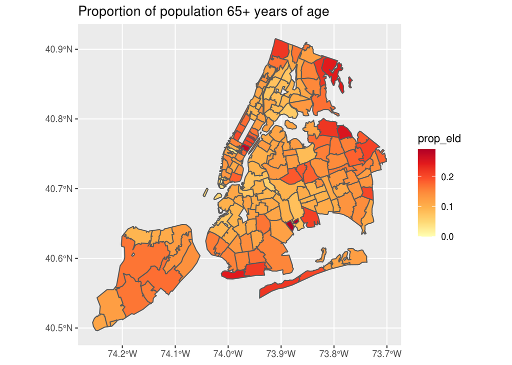

```r
ggplot(data = elderly, aes(fill = prop_eld)) +
  geom_sf() +
  scale_fill_distiller(palette = "YlOrRd",
                       direction = 1) +
  ggtitle("Proportion of population 65+ years of age")
```

```r
elderly_model <- lm(prop_COVID ~ prop_eld, data = elderly)
summary(elderly_model)
```

```
##
## Call:
## lm(formula = prop_COVID ~ prop_eld, data = elderly)
##
## Residuals:
##       Min        1Q    Median        3Q       Max
## -0.291187 -0.062872  0.009493  0.060647  0.249659
##
## Coefficients:
##             Estimate Std. Error t value Pr(>|t|)
## (Intercept)  0.54119    0.02068   26.16   <2e-16 ***
## prop_eld    -0.22266    0.14745   -1.51    0.133
## ---
## Signif. codes:  0 '***' 0.001 '**' 0.01 '*' 0.05 '.' 0.1 ' ' 1
##
## Residual standard error: 0.09423 on 175 degrees of freedom
## Multiple R-squared:  0.01286,    Adjusted R-squared:  0.007222
## F-statistic:  2.28 on 1 and 175 DF,  p-value: 0.1328
```

The r-squared value showed 1% in comparison to the 3% from the paper.

Now for Table 1. Where we make a linear model of 4 of the previous variables.

```r
#unisured, white, over3, income

#we must drop the geometry columns b/c you can't join with those columns
#comment in/out if needed
df_uninsured <- st_drop_geometry(df_uninsured)
race_white <- st_drop_geometry(race_white)

merged_table <- inner_join(df_uninsured, race_white, by="GEOID")

#comment in/out if needed
house_size <- st_drop_geometry(house_size)
med_inc <- st_drop_geometry(med_inc)
med_inc$GEOID <- as.numeric(med_inc$GEOID)
second_merged <- inner_join(house_size, med_inc, by="GEOID")

#merge everything for the linear model
merged_table$GEOID <- as.numeric(merged_table$GEOID)
full_merge <- inner_join(merged_table, second_merged, by="GEOID")

full_lm <- lm(prop_COVID.x.x ~ prop_four_up + pop_uninsured + prop_white + income_mil, data = full_merge)

#here are the confidence intervals and estimates
confidence_table1 <- confint(full_lm, level = 0.95)
estimates_table1 <- summary(full_lm)$coefficients

#Cleaner Table to see results
final_table1 <- data.frame(col1 = c('Intercept', 'Proportion of population living in households with more than 3 inhabitants', 'Proportion of the 18- to 64- year old population that is uninsured', 'Proportion of the population that self-identified their race as white', 'Median Household Income (2016$)'),
                           col2 = c(0.46, 0.33, 0.25, -0.09, -0.34),
                           col3 = c(0.41, 0.23, 0.04, -0.14, -0.76),
                           col4 = c(0.52, 0.44, 0.47, -0.04, 0.07)
)
colnames(final_table1) <- c('Variables', 'Estimate', '2.5%', '97.5%')
final_table1
```

```
##                                                                    Variables
## 1                                                                  Intercept
## 2 Proportion of population living in households with more than 3 inhabitants
## 3         Proportion of the 18- to 64- year old population that is uninsured
## 4      Proportion of the population that self-identified their race as white
## 5                                            Median Household Income (2016$)
##   Estimate  2.5% 97.5%
## 1     0.46  0.41  0.52
## 2     0.33  0.23  0.44
## 3     0.25  0.04  0.47
## 4    -0.09 -0.14 -0.04
## 5    -0.34 -0.76  0.07
```

R-Squared value

```r
summary(full_lm)$r.squared
```

```
## [1] 0.5489625
```

# Second Plots

Now for plot 2. Where we grab safegraph data and find the trend in change of mobility.

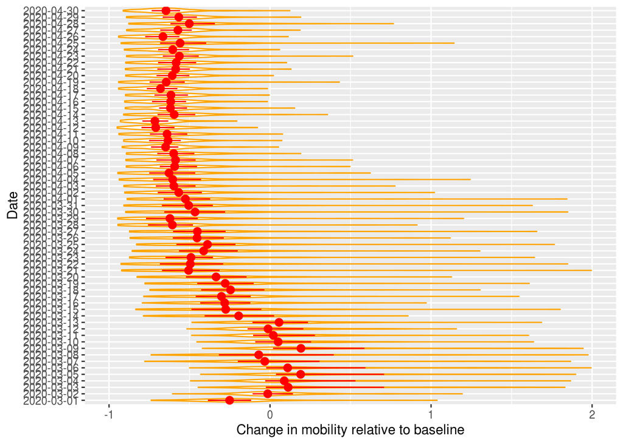

```r
load('/data/safegraph/safegraph.Rdata')

zippy <- read.csv("April_1_pos_tests.csv")
zippy <- zippy %>% mutate(postal_code = MODZCTA)

#zippy$postal_code <- as.numeric(zippy$postal_code)
safegraph <- inner_join(safegraph, zippy, by="postal_code")

safegraph <- safegraph[, -c(7:9)]

#to get the baseline, grab february and grab median of average visits per day
baseline_df <- safegraph %>% filter(grepl("^2020-02-", date))

baseline_df <- baseline_df %>% group_by(postal_code) %>% summarize(base_med = median(avg_visits_per_day))

#join the median of that zip code to the main table
safegraph <- inner_join(safegraph, baseline_df, by= "postal_code")

#get the difference from median
safegraph<- safegraph %>% mutate(change_base = (avg_visits_per_day - base_med) / base_med)

#make date into a factor for the graph
safegraph$date <- as.factor(safegraph$date)

#get rid of feb since it wasn't in the paper
safegraph <- safegraph %>% filter(grepl("^2020-03-", date) | grepl("^2020-04-", date))

#get median of all zips
dates_listy <- safegraph %>% group_by(date) %>% summarise(all_zip_med = median(change_base, na.rm=TRUE),
                                                          all_zip_quant_low = quantile(change_base, .25 ,na.rm=TRUE),
                                                          all_zip_quant_high = quantile(change_base, .75 ,na.rm=TRUE))

#plot
ggplot() +
  geom_violin(data = safegraph, aes(x = change_base, y = date), color = "orange") +
  geom_pointrange(data = dates_listy, aes(x = all_zip_med, y = date, xmin = all_zip_quant_low, xmax = all_zip_quant_high), color = "red") +
  xlim(-1,2) +
  xlab("Change in mobility relative to baseline") +
  ylab("Date")
```